# Graduate Admission Prediction

Amin Yakubu

4/3/2019

# Loading libraries

```r
library(tidyverse)
library(caret)
library(glmnet)
library(MASS)
library(e1071)
library(mlbench)
library(pROC)
library(AppliedPredictiveModeling)
library(gam)
library(car)
```

# Load Data

```r
admit_df = read_csv('data/Admission_Predict_Ver1.1.csv')
```

Checking for missing data

```r
sum(is.na(admit_df))
```

```
## [1] 0
```

Here, we see that we have no missing data in the dataset

Removal of unnecessary variables

```r
admit_df = admit_df %>% janitor::clean_names()
admit_df = admit_df[,-1]
```

The variable `serial_no` is removed.

```r
X = model.matrix(chance_of_admit~., admit_df)[,-1]
y = admit_df$chance_of_admit
```

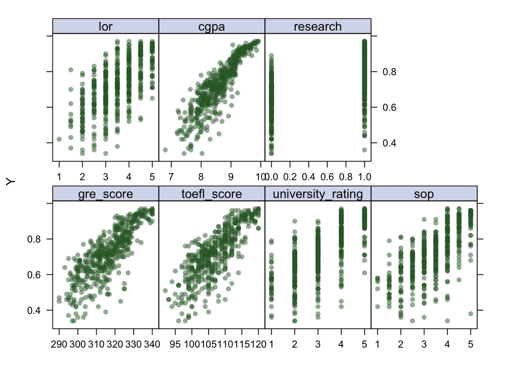

```r
theme1 <- trellis.par.get()
theme1$plot.symbol$col <- rgb(.2, .4, .2, .5)
theme1$plot.symbol$pch <- 16
theme1$plot.line$col <- rgb(.8, .1, .1, 1)
theme1$plot.line$lwd <- 2
theme1$strip.background$col <- rgb(.0, .2, .6, .2)
trellis.par.set(theme1)
featurePlot(X, y, plot = "scatter", labels = c("","Y"),
            type = c("p"), layout = c(4, 2))
```

Each predictor is plotted against the response, `chance_of_admit`. The continuous variables `cgpa`, `gre_score`, and `toefl_score` all have a positive linear relationship with the outcome. This also appears to be the case with the categorical variables, with the response increasing on average with each increase in predictor value.

From the plots we can see that most of our variables are linearly distributed. Because of that we will start with simple linear regression

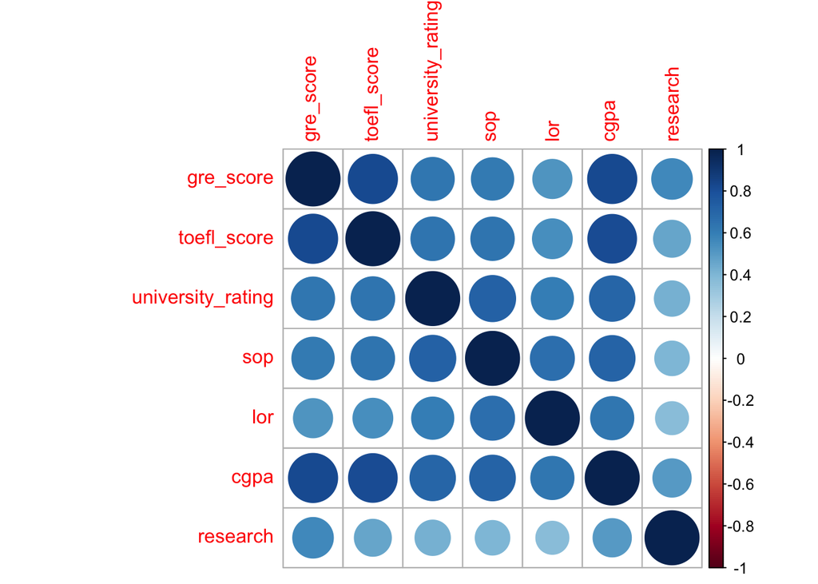

```r
corrplot::corrplot(cor(X))
```

The predictors in this dataset

```r
summary(admit_df)
```

```
##    gre_score      toefl_score    university_rating      sop
##  Min.   :290.0   Min.   : 92.0   Min.   :1.000     Min.   :1.000
##  1st Qu.:308.0   1st Qu.:103.0   1st Qu.:2.000     1st Qu.:2.500
##  Median :317.0   Median :107.0   Median :3.000     Median :3.500
##  Mean   :316.5   Mean   :107.2   Mean   :3.114     Mean   :3.374
##  3rd Qu.:325.0   3rd Qu.:112.0   3rd Qu.:4.000     3rd Qu.:4.000
##  Max.   :340.0   Max.   :120.0   Max.   :5.000     Max.   :5.000
##       lor             cgpa          research    chance_of_admit
##  Min.   :1.000   Min.   :6.800   Min.   :0.00   Min.   :0.3400
##  1st Qu.:3.000   1st Qu.:8.127   1st Qu.:0.00   1st Qu.:0.6300
##  Median :3.500   Median :8.560   Median :1.00   Median :0.7200
##  Mean   :3.484   Mean   :8.576   Mean   :0.56   Mean   :0.7217
##  3rd Qu.:4.000   3rd Qu.:9.040   3rd Qu.:1.00   3rd Qu.:0.8200
##  Max.   :5.000   Max.   :9.920   Max.   :1.00   Max.   :0.9700
```

Let’s start with a simple linear regression

```r
fit = lm(chance_of_admit~., admit_df)
summary(fit)
```

```
##
## Call:
## lm(formula = chance_of_admit ~ ., data = admit_df)
##
## Residuals:
##       Min        1Q    Median        3Q       Max
## -0.266657 -0.023327  0.009191  0.033714  0.156818
##
## Coefficients:
##                     Estimate Std. Error t value Pr(>|t|)
## (Intercept)       -1.2757251  0.1042962 -12.232  < 2e-16 ***
## gre_score          0.0018585  0.0005023   3.700 0.000240 ***
## toefl_score        0.0027780  0.0008724   3.184 0.001544 **
## university_rating  0.0059414  0.0038019   1.563 0.118753
## sop                0.0015861  0.0045627   0.348 0.728263
## lor                0.0168587  0.0041379   4.074 5.38e-05 ***
## cgpa               0.1183851  0.0097051  12.198  < 2e-16 ***
## research           0.0243075  0.0066057   3.680 0.000259 ***
## ---
## Signif. codes:  0 '***' 0.001 '**' 0.01 '*' 0.05 '.' 0.1 ' ' 1
##
## Residual standard error: 0.05999 on 492 degrees of freedom
## Multiple R-squared:  0.8219, Adjusted R-squared:  0.8194
## F-statistic: 324.4 on 7 and 492 DF,  p-value: < 2.2e-16
```

```r
vif(fit)
```

```
##         gre_score       toefl_score university_rating               sop
##          4.464249          3.904213          2.621036          2.835210
##               lor              cgpa          research
##          2.033555          4.777992          1.494008
```

We see that university rating and sop are not associated with chance of admission due to their large p values. We will remove the variables `university_rating` and `sop`.

Diagnositcs

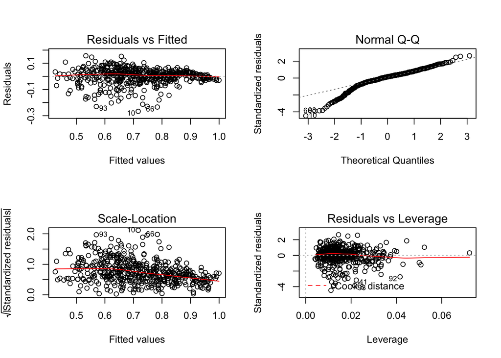

```r
par(mfrow = c(2,2))
plot(fit)
```

```r
admit_df = admit_df[,-c(3, 4)]
```

```r
X = model.matrix(chance_of_admit~., admit_df)[,-1]
y = admit_df$chance_of_admit
```

Find Linear Dependencies

```r
findLinearCombos(admit_df)
```

```
## $linearCombos
## list()
##
## $remove
## NULL
```

There are no linear dependencies and therefore no predictors need to be removed.

```r
ctrl1 <- trainControl(method = "repeatedcv", number = 10, repeats = 5)
```

# Linear Regression

```r
set.seed(2)
lm.fit <- train(X, y,
                method = "lm",
                trControl = ctrl1)

getTrainPerf(lm.fit)
```

```
##    TrainRMSE TrainRsquared   TrainMAE method
## 1 0.05988188     0.8214782 0.04332004     lm
```

# GAM

GRE score and toefl scores shows some none linear trends at the top

```r
set.seed(2)
gam.fit <- train(X, y,
                 method = "gam",
                 tuneGrid = data.frame(method = "GCV.Cp", select = c(TRUE, FALSE)),
                 trControl = ctrl1)

gam.fit$bestTune
```

```
##   select method
## 1  FALSE GCV.Cp
```

```r
gam.fit$finalModel
```

```
##
## Family: gaussian
## Link function: identity
##
## Formula:
## .outcome ~ research + lor + s(toefl_score) + s(gre_score) + s(cgpa)
##
## Estimated degrees of freedom:
## 1.23 1.00 5.81  total = 11.04
##
## GCV score: 0.003625701
```

## Multivariate Adaptive Regression Splines (MARS)

```r
library(pdp)
library(earth)
```

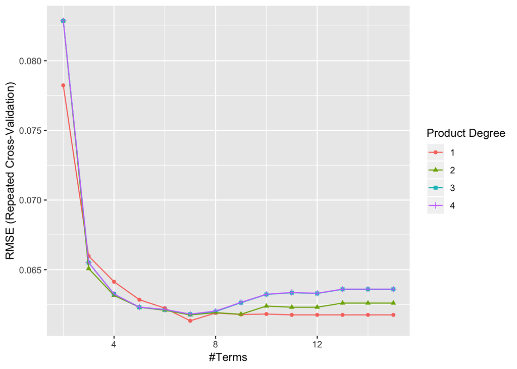

```r
mars_grid <- expand.grid(degree = 1:4,
                         nprune = 2:15)
set.seed(2)
mars.fit <- train(X, y,
                 method = "earth",
                 tuneGrid = mars_grid,
                 trControl = ctrl1)
ggplot(mars.fit)
```

```r
mars.fit$bestTune
```

```
##   nprune degree
## 6      7      1
```

```r
coef(mars.fit$finalModel)
```

```
##        (Intercept)        h(cgpa-8.6)        h(8.6-cgpa)
##        0.726194068        0.151132369       -0.116402503
##   h(334-gre_score)         h(lor-2.5) h(103-toefl_score)
##       -0.002198463        0.020092667       -0.007581152
##           research
##        0.025770406
```

To better understand the relationship between these features and `chance_of_admit`, we can create partial dependence plots (PDPs) for each feature individually and also an interaction PDP. This is used to examine the marginal effects of predictors.

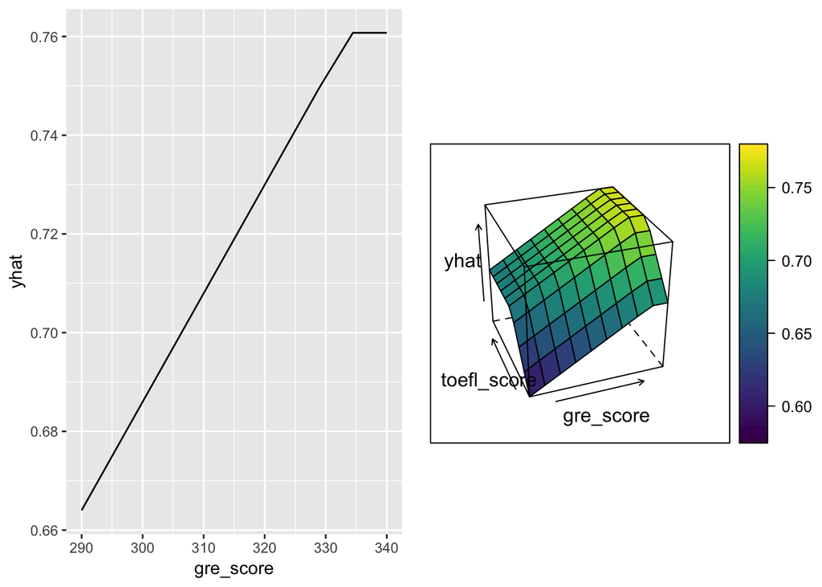

```r
p1 <- partial(mars.fit, pred.var = c("gre_score"), grid.resolution = 10) %>% autoplot()
p2 <- partial(mars.fit, pred.var = c("gre_score", "toefl_score"), grid.resolution = 10) %>% plotPartial(levelplot = FALSE, zlab = "yhat", drape = TRUE,
            screen = list(z = 20, x = -60))

grid.arrange(p1, p2, ncol = 2)
```

# Lasso

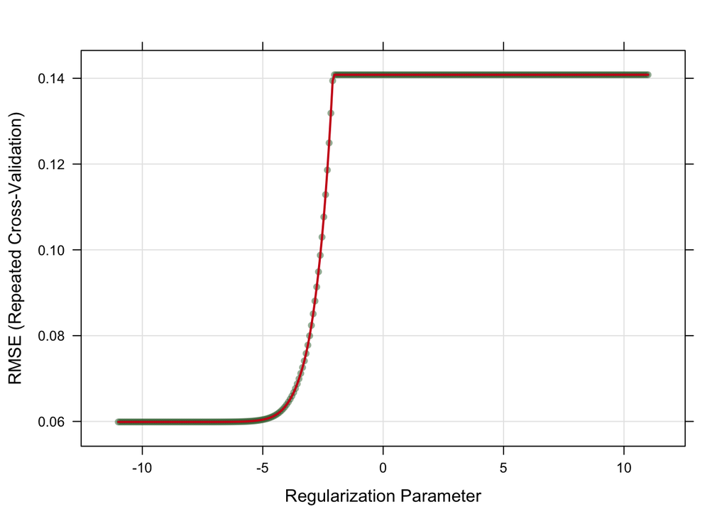

```r
set.seed(2)
lasso.fit <- train(X, y,
                     method = "glmnet",
                     tuneGrid = expand.grid(alpha = 1,
                                            lambda = exp(seq(-11,11, length = 300))),
                   # preProc = c("center", "scale"),
                     trControl = ctrl1)

plot(lasso.fit, xTrans = function(x) log(x))
```

```r
getTrainPerf(lasso.fit)
```

```
##   TrainRMSE TrainRsquared   TrainMAE method
## 1 0.0598804     0.8214237 0.04329024 glmnet
```

```r
lasso.fit$bestTune$lambda
```

```
## [1] 0.0006614539
```

# Ridge

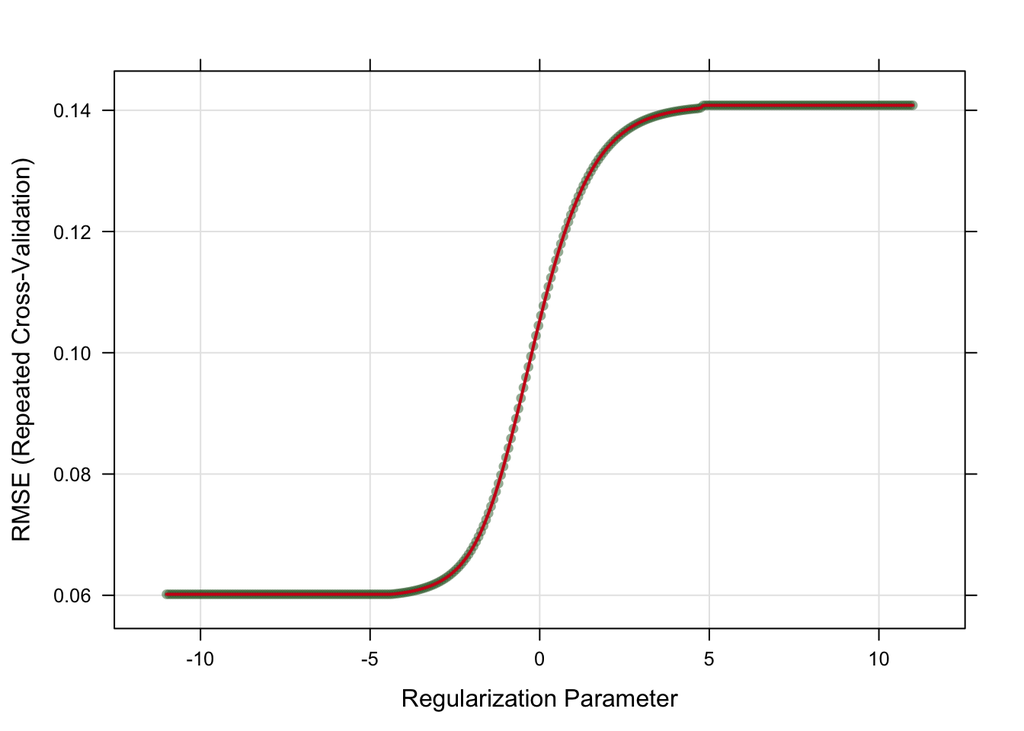

```r
set.seed(2)
ridge.fit <- train(X, y,
                     method = "glmnet",
                     tuneGrid = expand.grid(alpha = 0,
                                            lambda = exp(seq(-11, 11, length = 300))),
                     trControl = ctrl1)

plot(ridge.fit, xTrans = function(x) log(x))
```

```r
getTrainPerf(lasso.fit)
```

```
##   TrainRMSE TrainRsquared   TrainMAE method
## 1 0.0598804     0.8214237 0.04329024 glmnet
```

```r
ridge.fit$bestTune$lambda
```

```
## [1] 0.011661
```

# Elastic Net

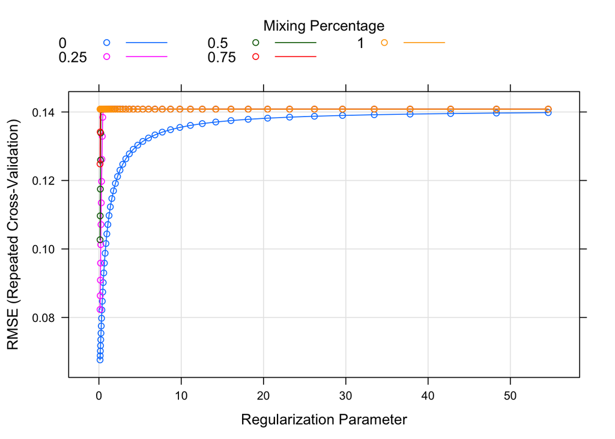

```r
set.seed(2)
enet.fit <- train(X, y,
                     method = "glmnet",
                     tuneGrid = expand.grid(alpha = seq(0, 1, length = 5),
                                            lambda = exp(seq(-2, 4, length = 50))),
                     trControl = ctrl1)

plot(enet.fit)
```

```r
enet.fit$bestTune
```

```
##   alpha    lambda
## 1     0 0.1353353
```

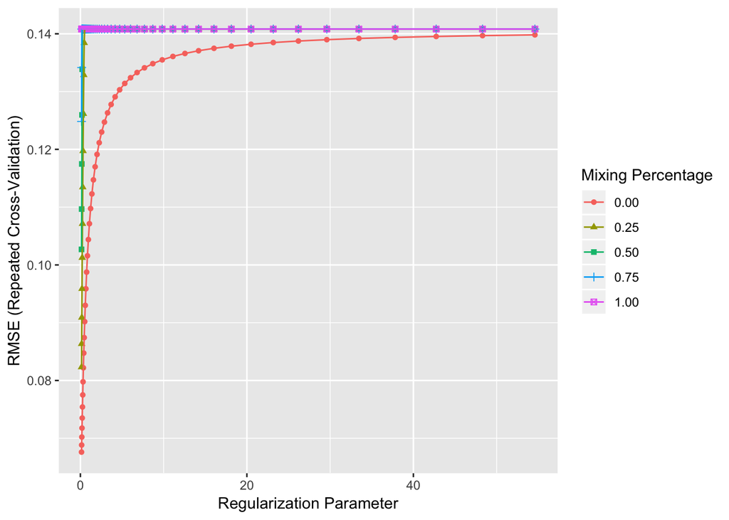

```r
ggplot(enet.fit)
```

# PCR

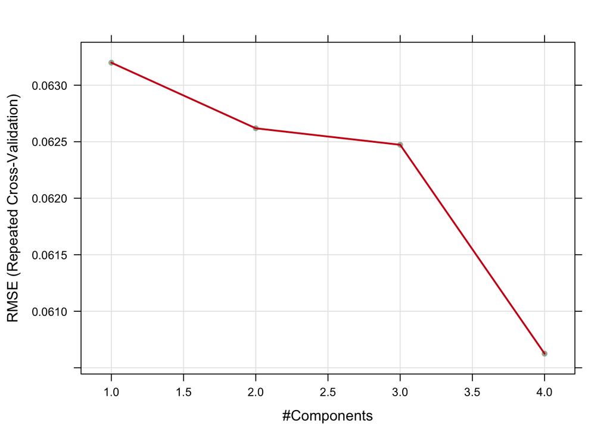

```r
set.seed(2)
pcr.fit <- train(X, y,
                 method = "pcr",
                 tuneLength = 7,
                 trControl = ctrl1,
                 scale = T)

plot(pcr.fit)
```

```r
pcr.pred <- predict(pcr.fit$finalModel, newdata = X,
                    ncomp = pcr.fit$bestTune$ncomp)

mean((pcr.pred - y)^2)
```

```
## [1] 0.003678139
```

```r
resamp <- resamples(list(lasso = lasso.fit,
                         ridge = ridge.fit,
                         pcr = pcr.fit,
                         lm = lm.fit,
                         enet = enet.fit,
                         mars = mars.fit,
                         gam = gam.fit))
summary(resamp)
```

```
##
## Call:
## summary.resamples(object = resamp)
##
## Models: lasso, ridge, pcr, lm, enet, mars, gam
## Number of resamples: 50
##
## MAE
##             Min.    1st Qu.     Median       Mean    3rd Qu.       Max.
## lasso 0.03328213 0.03989378 0.04292169 0.04329024 0.04621321 0.06117095
## ridge 0.03307237 0.04012080 0.04345391 0.04361371 0.04643648 0.06186262
## pcr   0.03286675 0.04096940 0.04373958 0.04383328 0.04613184 0.06052335
## lm    0.03345583 0.03978954 0.04299353 0.04332004 0.04626748 0.06111194
## enet  0.03933128 0.04814996 0.05127677 0.05129729 0.05294579 0.06727117
## mars  0.03477046 0.04194611 0.04456917 0.04499543 0.04837119 0.06332809
## gam   0.03198393 0.03936215 0.04239402 0.04274802 0.04643237 0.06066845
##       NA's
## lasso    0
## ridge    0
## pcr      0
## lm       0
## enet     0
## mars     0
## gam      0
##
## RMSE
##             Min.    1st Qu.     Median       Mean    3rd Qu.       Max.
## lasso 0.04510520 0.05439451 0.05872004 0.05988040 0.06458204 0.08012171
## ridge 0.04605685 0.05450304 0.05880035 0.06016358 0.06498789 0.08105431
## pcr   0.04545984 0.05495965 0.05921776 0.06062494 0.06596253 0.08122296
## lm    0.04530253 0.05429941 0.05871099 0.05988188 0.06464981 0.08004921
## enet  0.04906511 0.06339082 0.06720439 0.06760862 0.07163069 0.08847820
## mars  0.04576435 0.05582985 0.05990278 0.06133136 0.06608153 0.08250138
## gam   0.04327145 0.05421042 0.05758115 0.05997482 0.06522364 0.07955915
##       NA's
## lasso    0
## ridge    0
## pcr      0
## lm       0
## enet     0
## mars     0
## gam      0
##
## Rsquared
##            Min.   1st Qu.    Median      Mean   3rd Qu.      Max. NA's
## lasso 0.6873020 0.7903693 0.8360677 0.8214237 0.8544105 0.8985824    0
## ridge 0.6963411 0.7865811 0.8395627 0.8207473 0.8550247 0.8974418    0
## pcr   0.6785368 0.7788688 0.8364030 0.8170138 0.8516731 0.8968592    0
## lm    0.6885335 0.7904307 0.8358620 0.8214782 0.8543083 0.8984018    0
## enet  0.6932685 0.7778789 0.8280636 0.8119937 0.8495248 0.8847227    0
## mars  0.6658767 0.7787975 0.8231774 0.8123369 0.8497209 0.8964125    0
## gam   0.6972488 0.7867604 0.8335589 0.8204163 0.8550446 0.9058634    0
```

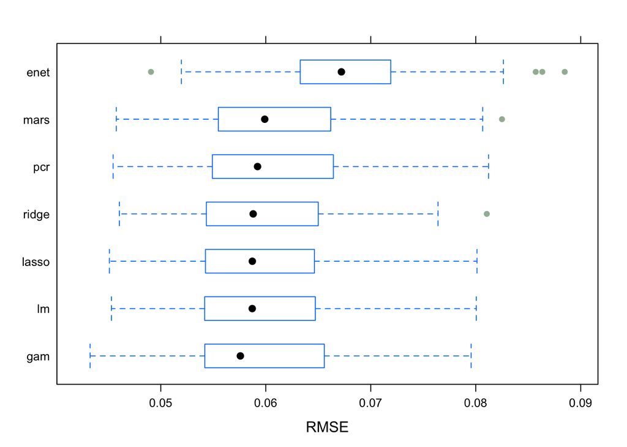

```r
bwplot(resamp, metric = "RMSE")
```